# Summary for linear models and generalized linear models

tommaso tarchi

2023-01-19

## Dataset

To avoid possible correlation between observations we use only data from one year.

```r
## importing the dataset and omitting the missing values
datafile <- read.csv("../WiscNursingHome.csv")
datafile <- na.omit(datafile)

## dividing data from different years
data_2000 <- datafile[datafile$CRYEAR == 2000, ]
rownames(data_2000) <- 1:nrow(data_2000)
data_2001 <- datafile[datafile$CRYEAR == 2001, ]
rownames(data_2001) <- 1:nrow(data_2001)

datafile$ORGSTR <- as.factor(datafile$ORGSTR)
datafile$MSA <- as.factor(datafile$MSA)

data_2000$UTILIZATION_RATE <- data_2000$TPY / data_2000$NUMBED
```

## Linear models

First let’s take a look at the model with just SQRFOOT as a predictor:

```r
summary(lm(TPY ~ SQRFOOT, data = data_2000))
```

```
##
## Call:
## lm(formula = TPY ~ SQRFOOT, data = data_2000)
##
## Residuals:
##      Min       1Q   Median       3Q      Max
## -112.400  -14.480   -2.031   15.815   95.235
##
## Coefficients:
##             Estimate Std. Error t value Pr(>|t|)
## (Intercept) 33.96946    2.44409   13.90   <2e-16 ***
## SQRFOOT      1.10251    0.04017   27.45   <2e-16 ***
## ---
## Signif. codes:  0 '***' 0.001 '**' 0.01 '*' 0.05 '.' 0.1 ' ' 1
##
## Residual standard error: 26.15 on 355 degrees of freedom
## Multiple R-squared:  0.6797, Adjusted R-squared:  0.6788
## F-statistic: 753.2 on 1 and 355 DF,  p-value: < 2.2e-16
```

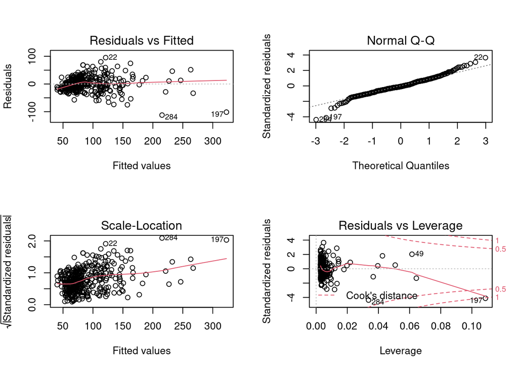

```r
par(mfrow = c(2, 2))
plot(lm(TPY ~ SQRFOOT, data = data_2000))
```

SQRFOOT seems to be a good predictor for TPY, but from the analysis of residuals we see that our model lacks the property of homoscedasticity and that there is at least one high leverage outlier. A possible way to fix these issues is to transform the variables somehow. After some attempts we found a linear relation between log(TPY) and log(SQRFOOT).

```r
summary(lm(log(TPY) ~ log(SQRFOOT), data = data_2000))
```

```
##
## Call:
## lm(formula = log(TPY) ~ log(SQRFOOT), data = data_2000)
##
## Residuals:
##      Min       1Q   Median       3Q      Max
## -1.73074 -0.14273  0.02319  0.19852  0.73846
##
## Coefficients:
##              Estimate Std. Error t value Pr(>|t|)
## (Intercept)   1.80509    0.09525   18.95   <2e-16 ***
## log(SQRFOOT)  0.68737    0.02523   27.25   <2e-16 ***
## ---
## Signif. codes:  0 '***' 0.001 '**' 0.01 '*' 0.05 '.' 0.1 ' ' 1
##
## Residual standard error: 0.2904 on 355 degrees of freedom
## Multiple R-squared:  0.6765, Adjusted R-squared:  0.6756
## F-statistic: 742.5 on 1 and 355 DF,  p-value: < 2.2e-16
```

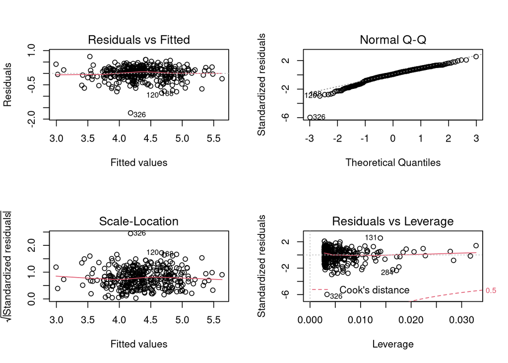

```r
par(mfrow = c(2, 2))
plot(lm(log(TPY) ~ log(SQRFOOT), data = data_2000))
```

### Adding categorical variables

```r
summary(lm(TPY ~ log(SQRFOOT) + URBAN + PRO + TAXEXEMPT + SELFFUNDINS + MCERT, data = data_2000))
```

```
##
## Call:
## lm(formula = TPY ~ log(SQRFOOT) + URBAN + PRO + TAXEXEMPT + SELFFUNDINS +
##     MCERT, data = data_2000)
##
## Residuals:
##     Min      1Q  Median      3Q     Max
## -75.878 -15.759   0.198  13.668 122.341
##
## Coefficients:
##               Estimate Std. Error t value Pr(>|t|)
## (Intercept)  -138.1600    11.3248 -12.200   <2e-16 ***
## log(SQRFOOT)   61.0819     2.6456  23.088   <2e-16 ***
## URBAN           2.6618     3.0173   0.882   0.3783
## PRO            -0.9424     5.0843  -0.185   0.8531
## TAXEXEMPT      -9.3995     5.0661  -1.855   0.0644 .
## SELFFUNDINS     0.4589     3.0450   0.151   0.8803
## MCERT           2.3347     5.1160   0.456   0.6484
## ---
## Signif. codes:  0 '***' 0.001 '**' 0.01 '*' 0.05 '.' 0.1 ' ' 1
##
## Residual standard error: 27.12 on 350 degrees of freedom
## Multiple R-squared:  0.6603, Adjusted R-squared:  0.6545
## F-statistic: 113.4 on 6 and 350 DF,  p-value: < 2.2e-16
```

```r
library(car)
vif(lm(TPY ~ log(SQRFOOT) + URBAN + PRO + TAXEXEMPT + SELFFUNDINS + MCERT, data = data_2000))
```

```
## log(SQRFOOT)        URBAN          PRO    TAXEXEMPT  SELFFUNDINS        MCERT
##     1.261115     1.099907     3.130564     2.911339     1.072570     1.151664
```

```r
AIC(lm(log(TPY) ~ log(SQRFOOT) + MCERT + factor(ORGSTR) + TAXEXEMPT + PRO, data = data_2000),
    lm(log(TPY) ~ log(SQRFOOT) + MCERT + factor(ORGSTR) + TAXEXEMPT, data = data_2000),
    lm(log(TPY) ~ log(SQRFOOT) + MCERT + factor(ORGSTR) + PRO, data = data_2000),
    lm(log(TPY) ~ log(SQRFOOT) + MCERT + TAXEXEMPT + PRO, data = data_2000),
    lm(log(TPY) ~ log(SQRFOOT) + MCERT + factor(ORGSTR), data = data_2000),
    lm(log(TPY) ~ log(SQRFOOT) + MCERT + PRO, data = data_2000),
    lm(log(TPY) ~ log(SQRFOOT) + MCERT + TAXEXEMPT, data = data_2000))
```

```
##                                                                                          df
## lm(log(TPY) ~ log(SQRFOOT) + MCERT + factor(ORGSTR) + TAXEXEMPT + PRO, data = data_2000)  6
## lm(log(TPY) ~ log(SQRFOOT) + MCERT + factor(ORGSTR) + TAXEXEMPT, data = data_2000)        6
## lm(log(TPY) ~ log(SQRFOOT) + MCERT + factor(ORGSTR) + PRO, data = data_2000)              6
## lm(log(TPY) ~ log(SQRFOOT) + MCERT + TAXEXEMPT + PRO, data = data_2000)                   6
## lm(log(TPY) ~ log(SQRFOOT) + MCERT + factor(ORGSTR), data = data_2000)                    6
## lm(log(TPY) ~ log(SQRFOOT) + MCERT + PRO, data = data_2000)                               5
## lm(log(TPY) ~ log(SQRFOOT) + MCERT + TAXEXEMPT, data = data_2000)                         5
##                                                                                               AIC
## lm(log(TPY) ~ log(SQRFOOT) + MCERT + factor(ORGSTR) + TAXEXEMPT + PRO, data = data_2000) 121.8597
## lm(log(TPY) ~ log(SQRFOOT) + MCERT + factor(ORGSTR) + TAXEXEMPT, data = data_2000)       121.8597
## lm(log(TPY) ~ log(SQRFOOT) + MCERT + factor(ORGSTR) + PRO, data = data_2000)             121.8597
## lm(log(TPY) ~ log(SQRFOOT) + MCERT + TAXEXEMPT + PRO, data = data_2000)                  121.8597
## lm(log(TPY) ~ log(SQRFOOT) + MCERT + factor(ORGSTR), data = data_2000)                   121.8597
## lm(log(TPY) ~ log(SQRFOOT) + MCERT + PRO, data = data_2000)                              121.4745
## lm(log(TPY) ~ log(SQRFOOT) + MCERT + TAXEXEMPT, data = data_2000)                        120.6592
```

It turns out that adding TAXEXEMPT is enough.

### Adding NUMBED

At this point our best model is the following (we report it with its diagnosis):

```r
fit.best <- lm(log(TPY) ~ log(SQRFOOT) + TAXEXEMPT, data = data_2000)
summary(fit.best)
```

```
##
## Call:
## lm(formula = log(TPY) ~ log(SQRFOOT) + TAXEXEMPT, data = data_2000)
##
## Residuals:
##      Min       1Q   Median       3Q      Max
## -1.65291 -0.15074  0.02506  0.19495  0.82921
##
## Coefficients:
##              Estimate Std. Error t value Pr(>|t|)
## (Intercept)   1.79793    0.09357  19.215  < 2e-16 ***
## log(SQRFOOT)  0.70110    0.02505  27.992  < 2e-16 ***
## TAXEXEMPT    -0.11807    0.03157  -3.741 0.000214 ***
## ---
## Signif. codes:  0 '***' 0.001 '**' 0.01 '*' 0.05 '.' 0.1 ' ' 1
##
## Residual standard error: 0.2853 on 354 degrees of freedom
## Multiple R-squared:  0.6888, Adjusted R-squared:  0.6871
## F-statistic: 391.8 on 2 and 354 DF,  p-value: < 2.2e-16
```

```r
anova(fit.best)
```

```
## Analysis of Variance Table
##
## Response: log(TPY)
##               Df Sum Sq Mean Sq F value    Pr(>F)
## log(SQRFOOT)   1 62.627  62.627 769.674 < 2.2e-16 ***
## TAXEXEMPT      1  1.138   1.138  13.992 0.0002141 ***
## Residuals    354 28.804   0.081
## ---
## Signif. codes:  0 '***' 0.001 '**' 0.01 '*' 0.05 '.' 0.1 ' ' 1
```

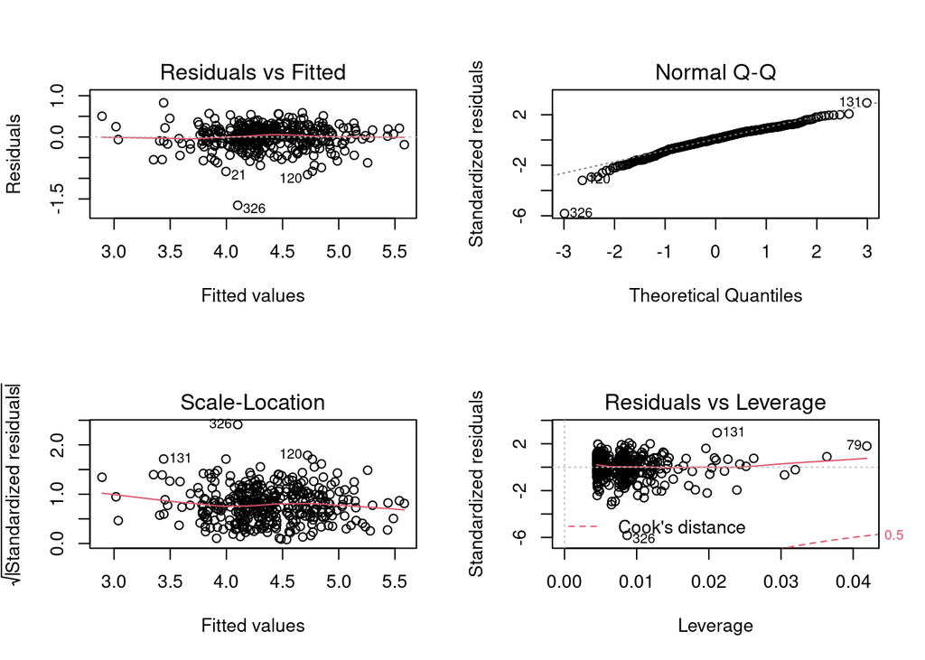

```r
par(mfrow = c(2, 2))
plot(fit.best)
```

We can observe that, apart from one or two outliers, the residuals satisfy the assumptions of homoscedasticity and normality.

```r
summary(lm(log(TPY) ~ log(NUMBED) + log(SQRFOOT) + TAXEXEMPT, data = data_2000))
```

```
##
## Call:
## lm(formula = log(TPY) ~ log(NUMBED) + log(SQRFOOT) + TAXEXEMPT,
##     data = data_2000)
##
## Residuals:
##      Min       1Q   Median       3Q      Max
## -0.87174 -0.01698  0.01996  0.05573  0.21374
##
## Coefficients:
##              Estimate Std. Error t value Pr(>|t|)
## (Intercept)  -0.15359    0.05990  -2.564   0.0108 *
## log(NUMBED)   1.00057    0.02370  42.219   <2e-16 ***
## log(SQRFOOT)  0.01149    0.01926   0.597   0.5510
## TAXEXEMPT     0.02964    0.01332   2.225   0.0267 *
## ---
## Signif. codes:  0 '***' 0.001 '**' 0.01 '*' 0.05 '.' 0.1 ' ' 1
##
## Residual standard error: 0.1161 on 353 degrees of freedom
## Multiple R-squared:  0.9486, Adjusted R-squared:  0.9481
## F-statistic:  2170 on 3 and 353 DF,  p-value: < 2.2e-16
```

We tried to include in the model SQRFOOT before NUMBED and vice versa, and we performed ANOVA and measured AIC. The outcome was that NUMBED was a much stronger predictor than SQRFOOT. In fact, as we can see in the following two chunks, adding SQRFOOT to a model that already contains NUMBED is basically irrelevant (also because the two varables are strongly correlated), if not even damaging to the model (because of added complexity):

```r
anova(lm(log(TPY) ~ log(SQRFOOT) + log(NUMBED) + MCERT + TAXEXEMPT, data = data_2000));
```

```
## Analysis of Variance Table
##
## Response: log(TPY)
##               Df Sum Sq Mean Sq   F value  Pr(>F)
## log(SQRFOOT)   1 62.627  62.627 4658.6248 < 2e-16 ***
## log(NUMBED)    1 25.114  25.114 1868.1849 < 2e-16 ***
## MCERT          1  0.014   0.014    1.0255 0.31192
## TAXEXEMPT      1  0.083   0.083    6.1404 0.01368 *
## Residuals    352  4.732   0.013
## ---
## Signif. codes:  0 '***' 0.001 '**' 0.01 '*' 0.05 '.' 0.1 ' ' 1
```

```r
anova(lm(log(TPY) ~ log(NUMBED) + log(SQRFOOT) + MCERT + TAXEXEMPT, data = data_2000))
```

```
## Analysis of Variance Table
##
## Response: log(TPY)
##               Df Sum Sq Mean Sq   F value  Pr(>F)
## log(NUMBED)    1 87.718  87.718 6525.0637 < 2e-16 ***
## log(SQRFOOT)   1  0.023   0.023    1.7461 0.18723
## MCERT          1  0.014   0.014    1.0255 0.31192
## TAXEXEMPT      1  0.083   0.083    6.1404 0.01368 *
## Residuals    352  4.732   0.013
## ---
## Signif. codes:  0 '***' 0.001 '**' 0.01 '*' 0.05 '.' 0.1 ' ' 1
```

```r
AIC(lm(log(TPY) ~ log(NUMBED) + log(SQRFOOT) + MCERT + TAXEXEMPT, data = data_2000),
    lm(log(TPY) ~ log(NUMBED) + MCERT + TAXEXEMPT, data = data_2000))
```

```
##                                                                                 df
## lm(log(TPY) ~ log(NUMBED) + log(SQRFOOT) + MCERT + TAXEXEMPT, data = data_2000)  6
## lm(log(TPY) ~ log(NUMBED) + MCERT + TAXEXEMPT, data = data_2000)                 5
##                                                                                       AIC
## lm(log(TPY) ~ log(NUMBED) + log(SQRFOOT) + MCERT + TAXEXEMPT, data = data_2000) -518.3265
## lm(log(TPY) ~ log(NUMBED) + MCERT + TAXEXEMPT, data = data_2000)                -520.0803
```

```r
anova(lm(log(TPY) ~ log(NUMBED) + log(SQRFOOT) + TAXEXEMPT, data = data_2000))
```

```
## Analysis of Variance Table
##
## Response: log(TPY)
##               Df Sum Sq Mean Sq   F value  Pr(>F)
## log(NUMBED)    1 87.718  87.718 6503.0259 < 2e-16 ***
## log(SQRFOOT)   1  0.023   0.023    1.7402 0.18797
## TAXEXEMPT      1  0.067   0.067    4.9528 0.02668 *
## Residuals    353  4.762   0.013
## ---
## Signif. codes:  0 '***' 0.001 '**' 0.01 '*' 0.05 '.' 0.1 ' ' 1
```

```r
AIC(lm(log(TPY) ~ log(NUMBED) + log(SQRFOOT) + TAXEXEMPT, data = data_2000),
    lm(log(TPY) ~ log(NUMBED) + TAXEXEMPT, data = data_2000))
```

```
##                                                                         df
## lm(log(TPY) ~ log(NUMBED) + log(SQRFOOT) + TAXEXEMPT, data = data_2000)  5
## lm(log(TPY) ~ log(NUMBED) + TAXEXEMPT, data = data_2000)                 4
##                                                                               AIC
## lm(log(TPY) ~ log(NUMBED) + log(SQRFOOT) + TAXEXEMPT, data = data_2000) -518.1060
## lm(log(TPY) ~ log(NUMBED) + TAXEXEMPT, data = data_2000)                -519.7459
```

The problem with NUMBED as a predictor arose when we analysed the residuals’ plots: in whatever way we included the variable (or its logarithm), the residuals were never meeting the assumptions of neither homoscedasticity or normality. In the following chunks we can see one of the many possible examples:

```r
summary(lm(log(TPY) ~ log(NUMBED) + TAXEXEMPT, data = data_2000))
```

```
##
## Call:
## lm(formula = log(TPY) ~ log(NUMBED) + TAXEXEMPT, data = data_2000)
##
## Residuals:
##      Min       1Q   Median       3Q      Max
## -0.87585 -0.01786  0.02008  0.05573  0.21599
##
## Coefficients:
##             Estimate Std. Error t value Pr(>|t|)
## (Intercept) -0.16520    0.05660  -2.919  0.00374 **
## log(NUMBED)  1.01257    0.01254  80.749  < 2e-16 ***
## TAXEXEMPT    0.03201    0.01270   2.520  0.01219 *
## ---
## Signif. codes:  0 '***' 0.001 '**' 0.01 '*' 0.05 '.' 0.1 ' ' 1
##
## Residual standard error: 0.116 on 354 degrees of freedom
## Multiple R-squared:  0.9485, Adjusted R-squared:  0.9482
## F-statistic:  3261 on 2 and 354 DF,  p-value: < 2.2e-16
```

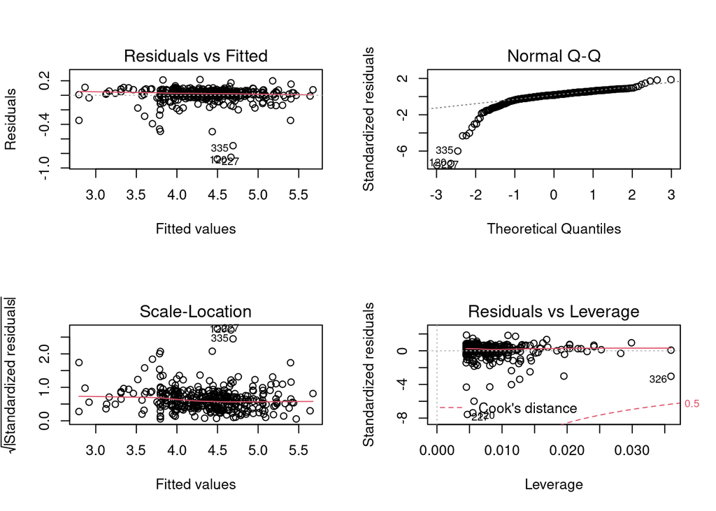

```r
par(mfrow = c(2, 2))
plot(lm(log(TPY) ~ log(NUMBED) + TAXEXEMPT, data = data_2000))
```

We can easily spot the presence of several outliers that seem to compromise both the assumptions.

The plots suggest that these outliers are observations for which TPY is a lot lower (and sometimes higher) than expected. This means that during the year these nursing houses have been underusing (and some of them overusing) their facilities. We can measure this “misuse” by the new variable we defined UTILIZATION_RATE.

### Removing outliers

For a mere illustration purpose we can remove the observations with the most extreme values of UTILIZATION_RATE and try to refit the model with NUMBED as a predictor.

Let’s inspect the UTILIZATION_RATE variable:

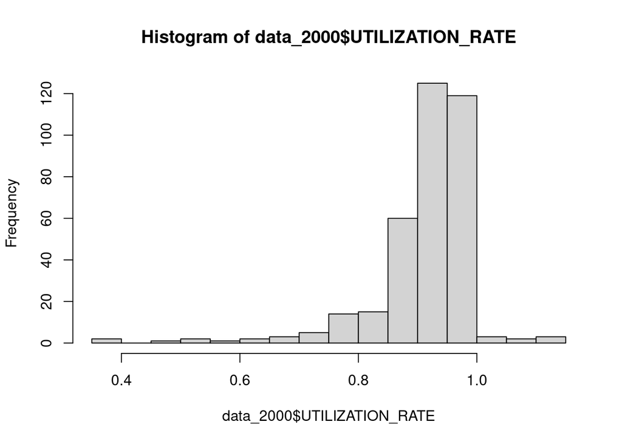

```r
hist(data_2000$UTILIZATION_RATE, breaks = 20);
```

```r
summary(data_2000$UTILIZATION_RATE)
```

```
##    Min. 1st Qu.  Median    Mean 3rd Qu.    Max.
##  0.3741  0.8944  0.9233  0.9128  0.9674  1.1355
```

After a couple of attempts, we found a good bound on UTILIZATION_RATE, for which the assumptions on the residuals were met. Here is the model:

```r
# removing outliers
data_trunc <- data_2000[data_2000$UTILIZATION_RATE > 0.85 & data_2000$UTILIZATION_RATE < 1.07, ]
rownames(data_trunc) <- 1:nrow(data_trunc)
```

```r
# fitting the model
fit.trunc.best <- lm(log(TPY) ~ log(NUMBED) + TAXEXEMPT, data = data_trunc)
summary(fit.trunc.best)
```

```
##
## Call:
## lm(formula = log(TPY) ~ log(NUMBED) + TAXEXEMPT, data = data_trunc)
##
## Residuals:
##       Min        1Q    Median        3Q       Max
## -0.097938 -0.029660 -0.000884  0.031572  0.140560
##
## Coefficients:
##              Estimate Std. Error t value Pr(>|t|)
## (Intercept) -0.088414   0.022144  -3.993 8.18e-05 ***
## log(NUMBED)  1.003001   0.004916 204.007  < 2e-16 ***
## TAXEXEMPT    0.020506   0.004826   4.249 2.86e-05 ***
## ---
## Signif. codes:  0 '***' 0.001 '**' 0.01 '*' 0.05 '.' 0.1 ' ' 1
##
## Residual standard error: 0.04128 on 306 degrees of freedom
## Multiple R-squared:  0.9927, Adjusted R-squared:  0.9927
## F-statistic: 2.084e+04 on 2 and 306 DF,  p-value: < 2.2e-16
```

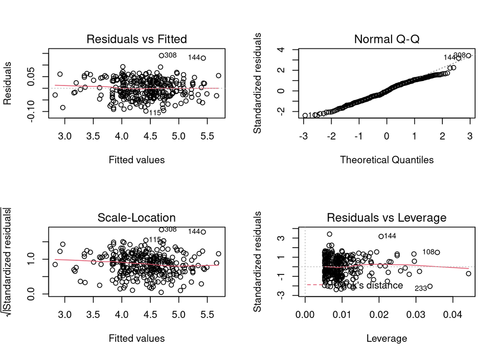

```r
par(mfrow = c(2, 2))
plot(fit.trunc.best)
```

Just to check the improvement we can compare the AIC score of this model with the previously found best model.

```r
# first we refit fit.best on the dataset without the outliers
fit.best2 <- lm(log(TPY) ~ log(SQRFOOT) + MCERT + TAXEXEMPT, data = data_trunc)

AIC(fit.best2, fit.trunc.best)
```

```
##                df         AIC
## fit.best2       5    41.75253
## fit.trunc.best  4 -1087.95550
```

This was just to show that for non extreme values of UTILIZATION_RATE log(NUMBED) is a strong linear predictor for log(TPY). Obviously this is not a usable model, since to compute UTILIZATION_RATE we need to know TPY in advance. However, it could be used in cases in which we have a method to estimate if UTILIZATION_RATE is likely to be extreme or not (for example using data from the previous years).

## Gamma models

A similar model to the linear one with log-transformed variables is the generalized linear model with gamma error structure and logarithmic link.

We tried to fit some models of this kind but, as expected, the results were not different from what we had found earlier. Again NUMBED turned out to be the strongest predictor, but with bad residuals.

```r
summary(glm(TPY ~ NUMBED + TAXEXEMPT, data = data_2000, family = Gamma(link = "log")))
```

```
##
## Call:
## glm(formula = TPY ~ NUMBED + TAXEXEMPT, family = Gamma(link = "log"),
##     data = data_2000)
##
## Deviance Residuals:
##      Min        1Q    Median        3Q       Max
## -0.99579  -0.06055   0.04702   0.11302   0.29649
##
## Coefficients:
##             Estimate Std. Error t value Pr(>|t|)
## (Intercept) 3.445450   0.021301 161.751   <2e-16 ***
## NUMBED      0.009537   0.000184  51.830   <2e-16 ***
## TAXEXEMPT   0.023413   0.018631   1.257     0.21
## ---
## Signif. codes:  0 '***' 0.001 '**' 0.01 '*' 0.05 '.' 0.1 ' ' 1
##
## (Dispersion parameter for Gamma family taken to be 0.02896432)
##
##     Null deviance: 89.271  on 356  degrees of freedom
## Residual deviance: 13.087  on 354  degrees of freedom
## AIC: 2960.7
##
## Number of Fisher Scoring iterations: 5
```

```r
summary(glm(TPY ~ log(NUMBED) + log(SQRFOOT) + TAXEXEMPT, data = data_2000,
            family = Gamma(link = "log")))
```

```
##
## Call:
## glm(formula = TPY ~ log(NUMBED) + log(SQRFOOT) + TAXEXEMPT, family = Gamma(link = "log"),
##     data = data_2000)
##
## Deviance Residuals:
##      Min        1Q    Median        3Q       Max
## -0.76708  -0.02198   0.01429   0.05186   0.21654
##
## Coefficients:
##              Estimate Std. Error t value Pr(>|t|)
## (Intercept)  -0.14440    0.04945  -2.920  0.00372 **
## log(NUMBED)   1.00118    0.01957  51.170  < 2e-16 ***
## log(SQRFOOT)  0.01012    0.01590   0.637  0.52468
## TAXEXEMPT     0.02700    0.01100   2.455  0.01458 *
## ---
## Signif. codes:  0 '***' 0.001 '**' 0.01 '*' 0.05 '.' 0.1 ' ' 1
##
## (Dispersion parameter for Gamma family taken to be 0.009193505)
##
##     Null deviance: 89.2713  on 356  degrees of freedom
## Residual deviance:  4.1443  on 353  degrees of freedom
## AIC: 2550.7
##
## Number of Fisher Scoring iterations: 4
```

```r
AIC(glm(TPY ~ NUMBED + SQRFOOT + TAXEXEMPT, data = data_2000, family = Gamma(link = "log")),
    glm(TPY ~ log(NUMBED) + log(SQRFOOT) + TAXEXEMPT, data = data_2000,
        family = Gamma(link = "log")),
    glm(TPY ~ log(NUMBED) + TAXEXEMPT, data = data_2000, family = Gamma(link = "log")),
    glm(TPY ~ log(SQRFOOT) + TAXEXEMPT, data = data_2000, family = Gamma(link = "log")))
```

```
##                                                                                                   df
## glm(TPY ~ NUMBED + SQRFOOT + TAXEXEMPT, data = data_2000, family = Gamma(link = "log"))            5
## glm(TPY ~ log(NUMBED) + log(SQRFOOT) + TAXEXEMPT, data = data_2000, family = Gamma(link = "log"))  5
## glm(TPY ~ log(NUMBED) + TAXEXEMPT, data = data_2000, family = Gamma(link = "log"))                 4
## glm(TPY ~ log(SQRFOOT) + TAXEXEMPT, data = data_2000, family = Gamma(link = "log"))                4
##                                                                                                        AIC
## glm(TPY ~ NUMBED + SQRFOOT + TAXEXEMPT, data = data_2000, family = Gamma(link = "log"))           2961.018
## glm(TPY ~ log(NUMBED) + log(SQRFOOT) + TAXEXEMPT, data = data_2000, family = Gamma(link = "log")) 2550.667
## glm(TPY ~ log(NUMBED) + TAXEXEMPT, data = data_2000, family = Gamma(link = "log"))                2548.986
## glm(TPY ~ log(SQRFOOT) + TAXEXEMPT, data = data_2000, family = Gamma(link = "log"))               3217.750
```

```r
library(DHARMa)
```

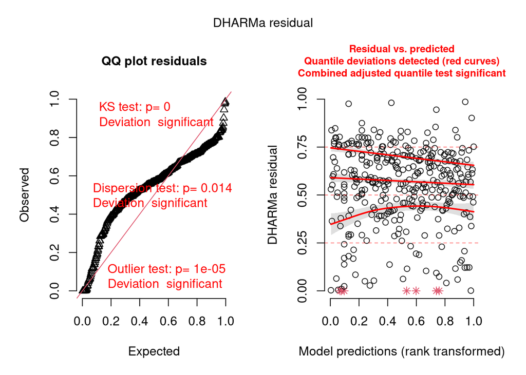

```r
q.sim1 <- simulateResiduals(glm(TPY ~ log(NUMBED) + TAXEXEMPT, data = data_2000,
                               family = Gamma(link = "log")), n = 1000)
plot(q.sim1)
```

```r
summary(glm(TPY ~ log(SQRFOOT) + TAXEXEMPT, data = data_2000, family = Gamma(link = "log")))
```

```
##
## Call:
## glm(formula = TPY ~ log(SQRFOOT) + TAXEXEMPT, family = Gamma(link = "log"),
##     data = data_2000)
##
## Deviance Residuals:
##     Min       1Q   Median       3Q      Max
## -1.3324  -0.1787  -0.0102   0.1691   0.8823
##
## Coefficients:
##              Estimate Std. Error t value Pr(>|t|)
## (Intercept)   1.85251    0.08644  21.432  < 2e-16 ***
## log(SQRFOOT)  0.69426    0.02314  30.007  < 2e-16 ***
## TAXEXEMPT    -0.09582    0.02916  -3.286  0.00112 **
## ---
## Signif. codes:  0 '***' 0.001 '**' 0.01 '*' 0.05 '.' 0.1 ' ' 1
##
## (Dispersion parameter for Gamma family taken to be 0.0694325)
##
##     Null deviance: 89.271  on 356  degrees of freedom
## Residual deviance: 26.719  on 354  degrees of freedom
## AIC: 3217.7
##
## Number of Fisher Scoring iterations: 5
```

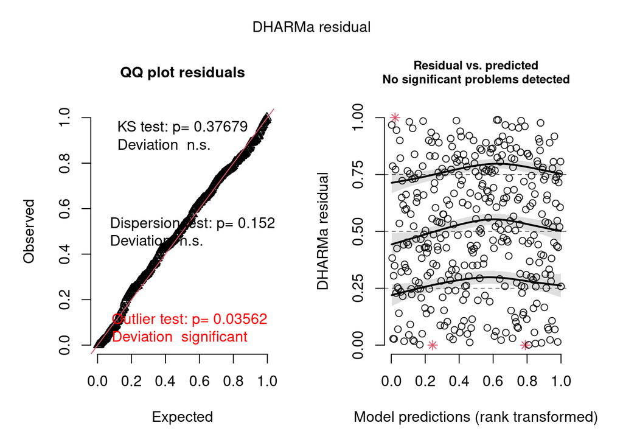

```r
q.sim2 <- simulateResiduals(glm(TPY ~ log(SQRFOOT) + TAXEXEMPT, data = data_2000,
                               family = Gamma(link = "log")), n = 1000)
plot(q.sim2)
```

```r
AIC(glm(TPY ~ NUMBED + MCERT + TAXEXEMPT, data = data_2000, family = Gamma(link = "log")),
    glm(TPY ~ SQRFOOT + MCERT + TAXEXEMPT, data = data_2000, family = Gamma(link = "log")))
```

```
##                                                                                        df
## glm(TPY ~ NUMBED + MCERT + TAXEXEMPT, data = data_2000, family = Gamma(link = "log"))   5
## glm(TPY ~ SQRFOOT + MCERT + TAXEXEMPT, data = data_2000, family = Gamma(link = "log"))  5
##                                                                                             AIC
## glm(TPY ~ NUMBED + MCERT + TAXEXEMPT, data = data_2000, family = Gamma(link = "log"))  2954.184
## glm(TPY ~ SQRFOOT + MCERT + TAXEXEMPT, data = data_2000, family = Gamma(link = "log")) 3331.387
```

Note on interpretation of the scatterplots above: in gamma generalized linear models there is no homoscedasticity, since gamma’s mean and variance change together. However, we can use the DHARMa package to simulate the expected distribution of residuals, and check the coherence with that of the true residuals.

```r
AIC(lm(log(TPY) ~ log(SQRFOOT) + TAXEXEMPT, data = data_2000),
    glm(TPY ~ log(SQRFOOT) + TAXEXEMPT, data = data_2000, family = Gamma(link = "log")))
```

```
##                                                                                     df
## lm(log(TPY) ~ log(SQRFOOT) + TAXEXEMPT, data = data_2000)                            4
## glm(TPY ~ log(SQRFOOT) + TAXEXEMPT, data = data_2000, family = Gamma(link = "log"))  4
##                                                                                           AIC
## lm(log(TPY) ~ log(SQRFOOT) + TAXEXEMPT, data = data_2000)                            122.4776
## glm(TPY ~ log(SQRFOOT) + TAXEXEMPT, data = data_2000, family = Gamma(link = "log")) 3217.7497
```